# Verify the Claim: Poverty Change in Philadelphia

- Show All Code
- Hide All Code
- View Source

Testing 2010 and 2017 ACS estimates for census tracts

Author

Thomas Hagos

Published

September 25, 2026

## The claim and the data

Alfred Lubrano’s [2018 WHYY article](https://whyy.org/articles/new-census-figures-on-philly-neighborhoods-show-inequality-high-numbers-of-whites-living-in-poverty/) reports that Eastwick’s poverty rate rose from 12% to 26% and Holmesburg’s from 2% to 19%. I wanted to see how much of the reported change is clear once I account for uncertainty in the ACS estimates.

I use Philadelphia census tracts from the 2006–2010 and 2013–2017 ACS five-year surveys. These periods do not overlap. I calculate poverty rates using `B17001_002` (people below poverty) divided by `B17001_001` (people whose poverty status was determined). The article does not list the tracts used for each neighborhood, so I test tract-level changes rather than reproduce its neighborhood figures.

```r
phillypoverty_2010 <- get_acs(
  geography = "tract",
  state = "PA",
  county= "Philadelphia",
  year = 2010,
variables = c(
    total_pop=
      "B17001_001",
    poverty_pop =
      "B17001_002"
  ),survey = "acs5"
  )
```

```r
phillypoverty_2017 <- get_acs(
  geography = "tract",
  state = "PA",
  county= "Philadelphia",
  year = 2017,
variables = c(
    total_pop=
      "B17001_001",
    poverty_pop =
      "B17001_002"
  ),survey = "acs5"
  )
```

```r
names(phillypoverty_2010)
head(phillypoverty_2010)

poverty_2010_wide <- phillypoverty_2010 |>
  tidyr::pivot_wider(
    names_from = variable,
    values_from = c(estimate, moe)
  )

head(poverty_2010_wide)
```

```r
poverty_2010_wide <- phillypoverty_2010 |>
  pivot_wider(
    names_from = variable,
    values_from = c(estimate, moe)
  )

poverty_2017_wide <- phillypoverty_2017 |>
  pivot_wider(
    names_from = variable,
    values_from = c(estimate, moe)
  )

names(poverty_2010_wide)
nrow(poverty_2010_wide)
nrow(poverty_2017_wide)
```

```r
poverty_2010_wide |>
  summarise(
    tracts = n(),
    zero_denominator = sum(estimate_total_pop == 0, na.rm = TRUE),
    missing_denominator = sum(is.na(estimate_total_pop))
  )

poverty_2017_wide |>
  summarise(
    tracts = n(),
    zero_denominator = sum(estimate_total_pop == 0, na.rm = TRUE),
    missing_denominator = sum(is.na(estimate_total_pop))
  )
```

```r
poverty_2010_rates <- poverty_2010_wide |>
  mutate(
    poverty_rate = if_else(
      estimate_total_pop > 0,
      estimate_poverty_pop / estimate_total_pop,
      NA_real_
    ),
    poverty_rate_moe = if_else(
      estimate_total_pop > 0,
      moe_prop(
        estimate_poverty_pop,
        estimate_total_pop,
        moe_poverty_pop,
        moe_total_pop
      ),
      NA_real_
    )
  )

poverty_2010_rates |>
  select(GEOID, poverty_rate, poverty_rate_moe) |>
  head()
```

```r
poverty_2017_rates <- poverty_2017_wide |>
  mutate(
    poverty_rate = if_else(
      estimate_total_pop > 0,
      estimate_poverty_pop / estimate_total_pop,
      NA_real_
    ),
    poverty_rate_moe = if_else(
      estimate_total_pop > 0,
      moe_prop(
        estimate_poverty_pop,
        estimate_total_pop,
        moe_poverty_pop,
        moe_total_pop
      ),
      NA_real_
    )
  )

poverty_2017_rates |>
  select(GEOID, poverty_rate, poverty_rate_moe) |>
  head()
```

```r
poverty_2010_rates <- poverty_2010_rates |>
  mutate(
    cv = (poverty_rate_moe / 1.645) / poverty_rate,
    reliability = case_when(
      is.na(cv) | !is.finite(cv) ~ "Undefined",
      cv < 0.12 ~ "Reliable",
      cv <= 0.40 ~ "Somewhat reliable",
      TRUE ~ "Unreliable"
    )
  )

poverty_2017_rates <- poverty_2017_rates |>
  mutate(
    cv = (poverty_rate_moe / 1.645) / poverty_rate,
    reliability = case_when(
      is.na(cv) | !is.finite(cv) ~ "Undefined",
      cv < 0.12 ~ "Reliable",
      cv <= 0.40 ~ "Somewhat reliable",
      TRUE ~ "Unreliable"
    )
  )

count(poverty_2010_rates, reliability)
count(poverty_2017_rates, reliability)
```

```r
poverty_2017_rates |>
  filter(reliability == "Undefined") |>
  select(
    GEOID, NAME,
    estimate_total_pop, estimate_poverty_pop,
    poverty_rate, poverty_rate_moe, cv
  )
```

```r
poverty_2010_rates |>
  filter(reliability == "Undefined") |>
  select(
    GEOID, NAME,
    estimate_total_pop, estimate_poverty_pop,
    poverty_rate, poverty_rate_moe, cv
  )
```

```r
tract_pairs <- poverty_2010_rates |>
  select(
    GEOID,
    rate_2010 = poverty_rate,
    moe_2010 = poverty_rate_moe
  ) |>
  inner_join(
    poverty_2017_rates |>
      select(
        GEOID,
        rate_2017 = poverty_rate,
        moe_2017 = poverty_rate_moe
      ),
    by = "GEOID"
  )

tract_pairs |>
  summarise(
    matched = n(),
    usable = sum(
      !is.na(rate_2010) & !is.na(moe_2010) &
      !is.na(rate_2017) & !is.na(moe_2017)
    )
  )
```

```r
tract_change <- tract_pairs |>
  filter(
    !is.na(rate_2010), !is.na(moe_2010),
    !is.na(rate_2017), !is.na(moe_2017)
  ) |>
  mutate(
    change_pp = 100 * (rate_2017 - rate_2010),
    change_moe_pp = 100 * sqrt(moe_2010^2 + moe_2017^2),
    detectable = abs(change_pp) > change_moe_pp
  )

tract_change |>
  summarise(
    tested = n(),
    detectable_increase = sum(detectable & change_pp > 0),
    detectable_decrease = sum(detectable & change_pp < 0),
    not_detectable = sum(!detectable)
  )
```

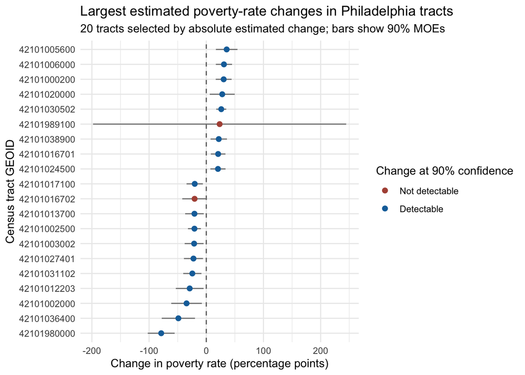

```r
#| fig-cap: "Largest estimated tract poverty-rate changes with 90% margins of error. Source: ACS 2006–2010 and 2013–2017 five-year estimates, table B17001."

tract_change |>
  slice_max(order_by = abs(change_pp), n = 20, with_ties = FALSE) |>
  mutate(GEOID = reorder(GEOID, change_pp)) |>
  ggplot(aes(y = GEOID)) +
  geom_vline(xintercept = 0, linetype = "dashed", color = "gray40") +
  geom_segment(
    aes(
      x = change_pp - change_moe_pp,
      xend = change_pp + change_moe_pp,
      yend = GEOID
    ),
    color = "gray50"
  ) +
  geom_point(aes(x = change_pp, color = detectable), size = 2) +
  scale_color_manual(
    values = c("TRUE" = "#1670A9", "FALSE" = "#B05243"),
    labels = c("TRUE" = "Detectable", "FALSE" = "Not detectable")
  ) +
  labs(
    title = "Largest estimated poverty-rate changes in Philadelphia tracts",
    subtitle = "20 tracts selected by absolute estimated change; bars show 90% MOEs",
    x = "Change in poverty rate (percentage points)",
    y = "Census tract GEOID",
    color = "Change at 90% confidence"
  ) +
  theme_minimal()
```

One of the largest estimated changes in the chart has a very wide margin of error that crosses zero. Its size alone does not establish that the tract’s poverty rate changed.

## Reliability of tract poverty estimates

This table counts tracts by the reliability of their poverty-rate estimates in each period.

```r
reliability_table <- bind_rows(
  mutate(poverty_2010_rates, Period = "2006–2010"),
  mutate(poverty_2017_rates, Period = "2013–2017")
) |>
  count(Period, reliability) |>
  mutate(Symbol = case_when(
    reliability == "Reliable" ~ "✓",
    reliability == "Somewhat reliable" ~ "~",
    reliability == "Unreliable" ~ "!",
    TRUE ~ "?"
  )) |>
  select(Period, Symbol, Reliability = reliability, Tracts = n)

knitr::kable(
  reliability_table,
  caption = "Reliability of Philadelphia tract poverty-rate estimates"
)
```

Reliability of Philadelphia tract poverty-rate estimates

| Period | Symbol | Reliability | Tracts |
| --- | --- | --- | --- |
| 2006–2010 | ✓ | Reliable | 11 |
| 2006–2010 | ~ | Somewhat reliable | 321 |
| 2006–2010 | ? | Undefined | 9 |
| 2006–2010 | ! | Unreliable | 43 |
| 2013–2017 | ✓ | Reliable | 22 |
| 2013–2017 | ~ | Somewhat reliable | 332 |
| 2013–2017 | ? | Undefined | 8 |
| 2013–2017 | ! | Unreliable | 22 |

*Source: ACS 5-year estimates. Jurjevich et al. (2018) CV thresholds: ✓ reliable (below 12%); ~ somewhat reliable (12–40%); ! unreliable (above 40%); ? undefined.*

Most tract poverty-rate estimates were classified as somewhat reliable: 321 of 384 in 2006–2010 and 332 of 384 in 2013–2017. These counts describe each period separately; they do not establish whether an individual tract’s estimate became more reliable over time.

## How many tract changes were detectable?

The chart counts matched tracts by the result of the 90% change test.

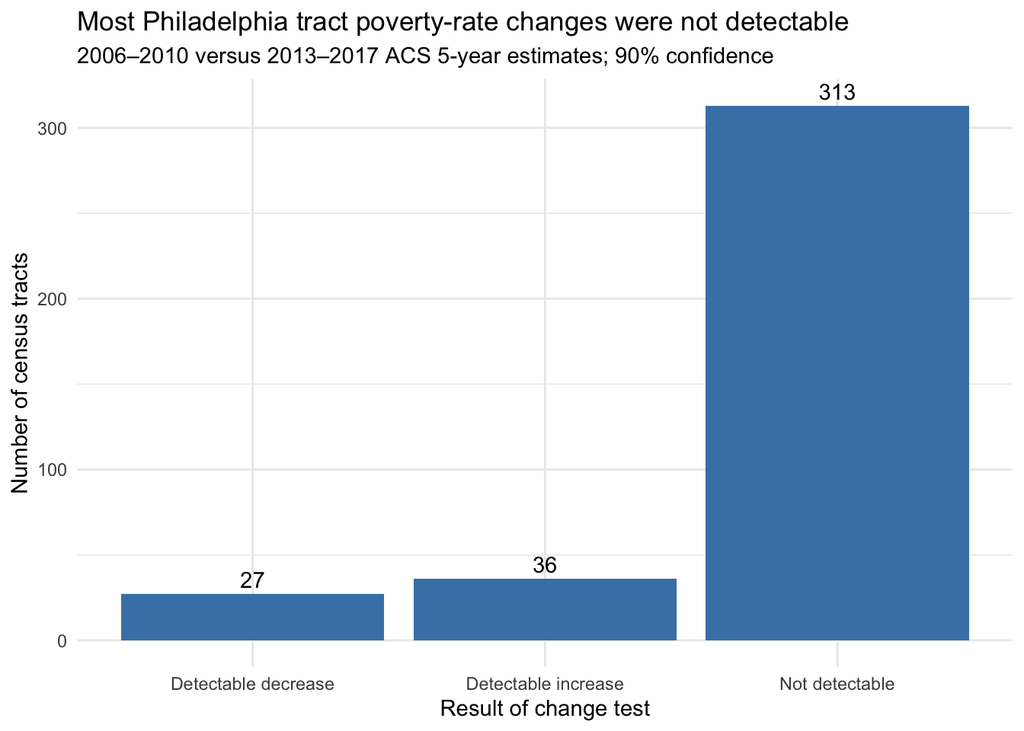

```r
change_counts <- data.frame(
  Result = c("Detectable increase", "Detectable decrease", "Not detectable"),
  Tracts = c(
    sum(tract_change$detectable & tract_change$change_pp > 0),
    sum(tract_change$detectable & tract_change$change_pp < 0),
    sum(!tract_change$detectable)
  )
)

ggplot(change_counts, aes(x = Result, y = Tracts)) +
  geom_col(fill = "steelblue") +
  geom_text(aes(label = Tracts), vjust = -0.4) +
  labs(
    title = "Most Philadelphia tract poverty-rate changes were not detectable",
    subtitle = "2006–2010 versus 2013–2017 ACS 5-year estimates; 90% confidence",
    x = "Result of change test",
    y = "Number of census tracts"
  ) +
  theme_minimal()
```

Among 376 tracts with usable comparisons, 36 showed a detectable increase in the poverty rate and 27 showed a detectable decrease at 90% confidence. For the other 313 tracts, the estimated change was not distinguishable from zero. This does not prove their poverty rates stayed constant; the ACS estimates are too uncertain to establish a change using this test.

## Why were some tracts excluded?

```r
tract_pairs |>
  summarise(across(everything(), ~sum(is.na(.))))
```

```r
tract_pairs |>
  filter(is.na(rate_2010) | is.na(rate_2017))
```

```r
names(poverty_2017_rates)
```

```r
poverty_2017_rates |>
  filter(is.na(poverty_rate)) |>
  select(GEOID, NAME, estimate_total_pop, estimate_poverty_pop)
```

```r
poverty_2010_rates |>
  filter(is.na(poverty_rate)) |>
  select(GEOID, NAME, estimate_total_pop, estimate_poverty_pop)
```

I started with 384 tracts that appeared in both ACS periods, but I could only test changes for 376. I checked the eight excluded tracts instead of assuming their missing rates meant zero poverty. Seven had no calculable rate in either period, and one had a rate in 2006–2010 but none in 2013–2017. Wherever a rate was missing, the estimated population covered by the poverty measure was zero. That makes the rate impossible to calculate, so I left those tracts out of the change test.

## What does the evidence support?

**Supported:** I found detectable poverty-rate changes in some Philadelphia census tracts. Of the 376 tracts I could compare, 36 had an increase and 27 had a decrease at 90% confidence.

**Cannot be determined:** I cannot check the article’s exact numbers for Eastwick, Holmesburg, or Fairhill with the tract data I used. The article gives neighborhood figures but does not say which tracts were included in each neighborhood. I would be guessing if I assigned tracts to those names. My calculations also cover poverty among everyone in the poverty measure, so they cannot test the article’s discussion of white poverty.

**Not supported:** My results do not support reading the article as evidence that poverty rates clearly rose across most Philadelphia tracts. Only 36 of the 376 tracts had a detectable increase; 27 had a detectable decrease, and 313 had no detectable change. That does not mean the article’s Eastwick or Holmesburg figures are wrong. My tract analysis cannot settle those neighborhood claims.

## Rewrite

Philadelphia’s poverty rates did not move in one clear direction across the city. Comparing the 2006–2010 and 2013–2017 surveys, I found detectable increases in 36 census tracts and detectable decreases in 27. In 313 other tracts, the data did not establish whether poverty changed. These results show why a large estimated jump should be checked against its margin of error before calling it a clear increase. The article reports increases for Eastwick and Holmesburg, but without its neighborhood boundaries, I cannot verify those specific figures from tract data.